# MovieLens Project by Warren Camp

### Project - MovieLens Data Analysis by Warren Camp

The GroupLens Research Project is a research group in the Department of Computer Science and Engineering at the University of Minnesota. The data is widely used for collaborative filtering and other filtering solutions. However, we will be using this data to act as a means to demonstrate our skill in using Python to “play” with data.

#### Domain

Internet and Entertainment

**Note that the project will need you to apply the concepts of groupby and merging extensively.**

Project - MovieLens Data Analysis

#### 1. Import the necessary packages - 2.5 marks

```python
# Import Python Libraries
import matplotlib.pyplot as plt
import seaborn as sns
import numpy as np
import pandas as pd
from sklearn.preprocessing import MinMaxScaler, Normalizer # Creates values {0, 1}

# Show plots
%matplotlib inline

sns.set(color_codes=True)
```

#### 2. Read the 3 datasets into dataframes - 2.5 marks

```python
# Read in the data set
df_data = pd.DataFrame(pd.read_csv('Data.csv', delimiter=","))
print('data = \n', df_data.head(5))
df_item = pd.DataFrame(pd.read_csv('item.csv', delimiter=","))
print('item = \n', df_item.head(5))
df_user = pd.DataFrame(pd.read_csv('user.csv', delimiter=","))
print('user = \n', df_user.head(5))
```

```
data =
    user id  movie id  rating  timestamp
0      196       242       3  881250949
1      186       302       3  891717742
2       22       377       1  878887116
3      244        51       2  880606923
4      166       346       1  886397596
item =
    movie id  movie title release date  unknown  Action  Adventure  Animation  \
0         1   Toy Story   01-Jan-1995        0       0          0          1
1         2   GoldenEye   01-Jan-1995        0       1          1          0
2         3  Four Rooms   01-Jan-1995        0       0          0          0
3         4  Get Shorty   01-Jan-1995        0       1          0          0
4         5     Copycat   01-Jan-1995        0       0          0          0

```

[output cut: 22 more lines]

#### 3. Apply info, shape, describe, and find the number of missing values in the data - 5 marks

```python
print('Data shape = \n', df_data.shape)
print('Data describe = \n', df_data.describe)
print('Data count null = \n',df_data.isnull().sum().sum())   #Looking for the number of missing values
print('Item shape = \n', df_item.shape)
print('Item describe = \n', df_item.describe)                #Looking for the number of missing values
print('Item count null = \n',df_item.isnull().sum().sum())
print('User shape = \n', df_user.shape)
print('User describe = \n', df_user.describe)
print('User count null = \n',df_user.isnull().sum().sum())    #Looking for the number of missing values
```

```
Data shape =
 (100000, 4)
Data describe =
 <bound method NDFrame.describe of        user id  movie id  rating  timestamp
0          196       242       3  881250949
1          186       302       3  891717742
2           22       377       1  878887116
3          244        51       2  880606923
4          166       346       1  886397596
...        ...       ...     ...        ...
99995      880       476       3  880175444
99996      716       204       5  879795543
99997      276      1090       1  874795795
99998       13       225       2  882399156
99999       12       203       3  879959583

[100000 rows x 4 columns]>
Data count null =
 0
Item shape =
 (1681, 22)
Item describe =
 <bound method NDFrame.describe of       movie id                          movie title release date  unknown  \
0            1                           Toy Story   01-Jan-1995        0
1            2                           GoldenEye   01-Jan-1995        0
2            3                          Four Rooms   01-Jan-1995        0
3            4                          Get Shorty   01-Jan-1995        0
4            5                             Copycat   01-Jan-1995        0
...        ...                                  ...          ...      ...
1676      1678                          Mat' i syn   06-Feb-1998        0
1677      1679                           B. Monkey   06-Feb-1998        0
1678      1680                       Sliding Doors   01-Jan-1998        0
1679      1681                        You So Crazy   01-Jan-1994        0
1680      1682  Scream of Stone (Schrei aus Stein)   08-Mar-1996        0

      Action  Adventure  Animation  Childrens  Comedy  Crime  ...  Fantasy  \
0          0          0          1          1       1      0  ...        0
1          1          1          0          0       0      0  ...        0
2          0          0          0          0       0      0  ...        0
3          1          0          0          0       1      0  ...        0
```

[output cut: 41 more lines]

```
0          1   24      M     technician    85711
1          2   53      F          other    94043
2          3   23      M         writer    32067
3          4   24      M     technician    43537
4          5   33      F          other    15213
..       ...  ...    ...            ...      ...
938      939   26      F        student    33319
939      940   32      M  administrator    02215
940      941   20      M        student    97229
941      942   48      F      librarian    78209
942      943   22      M        student    77841

[943 rows x 5 columns]>
User count null =
 0
```

#### 4. Find the number of movies per genre using the item data - 5 marks

```python
# use sum on the default axis
genre = df_item[['unknown', 'Action',
       'Adventure', 'Animation', 'Childrens', 'Comedy', 'Crime', 'Documentary',
       'Drama', 'Fantasy', 'Film-Noir', 'Horror', 'Musical', 'Mystery',
       'Romance', 'Sci-Fi', 'Thriller', 'War', 'Western']]
print('Number of movies per genre = \n', genre.sum(axis=0))
```

```
Number of movies per genre =
 unknown          1
Action         251
Adventure      135
Animation       42
Childrens      122
Comedy         505
Crime          109
Documentary     50
Drama          725
Fantasy         22
Film-Noir       24
Horror          92
Musical         56
Mystery         61
Romance        247
Sci-Fi         101
Thriller       251
War             71
Western         27
dtype: int64
```

#### 5. Find the movies that have more than one genre - 2.5 marks

```python
#hint: use sum on the axis = 1
df_item['sum'] = genre.sum(axis=1) # add sum column to df_item dataframe
mat = df_item['sum'] > 1           # identify those movies where sum = 1 as False
movies = df_item[mat]
print('Number of genre greater than 1 per movie  = \n', movies[['sum', 'movie title']])
```

```
Number of genre greater than 1 per movie  =
       sum         movie title
0       3          Toy Story
1       3          GoldenEye
3       3         Get Shorty
4       3            Copycat
6       2     Twelve Monkeys
...   ...                 ...
1667    3  MURDER and murder
1668    2            Tainted
1671    2             Mirage
1677    2          B. Monkey
1678    2      Sliding Doors

[849 rows x 2 columns]
```

#### 6. Drop the movie where the genre is unknown - 2.5 marks

```python
df_item_copy = df_item
print(df_item.shape) # Show the number of rows currently in the dataframe
print(df_item.size)  # Show the size of the current dataframe
mat = df_item['unknown']==0
print(mat)
df_item = df_item[mat].copy()
print(df_item.shape) # Show the dataframe has one less row
print(df_item.size)  # Show the size of the dataframe has been reduces by 23 (38663 - 38640)
```

```
(1681, 23)
38663
0       True
1       True
2       True
3       True
4       True
        ...
1676    True
1677    True
1678    True
1679    True
1680    True
Name: unknown, Length: 1681, dtype: bool
(1680, 23)
38640
```

### 7. Univariate plots of columns: 'rating', 'Age', 'release year', 'Gender' and 'Occupation' - 10 marks

```python
# HINT: use distplot for age and countplot for gender,ratings,occupation.
# HINT: Please refer to the below snippet to understand how to get to release year from release date. You can use str.split()
# as depicted below
# Hint : Use displot without kde for release year or line plot showing year wise count.
```

```python
a = 'My*cat*is*brown'
print(a.split('*')[3])

#similarly, the release year needs to be taken out from release date

#also you can simply slice existing string to get the desired data, if we want to take out the colour of the cat

print(a[10:])
print(a[-5:])
```

```
brown
brown
brown
```

```python
##  your answers here
df_year = pd.DataFrame(columns=['Year'], index=np.arange(1681))   #Create temporary dataframe used to contain the year
df_item = df_item_copy  #Correct error caused by the missing index in df_item after removing the unknown movie
# HINT: Please refer to the below snippet to understand how to get to release year from release date. You can use str.split()
for i in range(1681):
        df_year.iloc[i] = (str(df_item.iloc[i]['release date'].split('-')[2]))   # remove the year from the date field
df_item['Year'] = df_year  # add the year as a new column in df_item

print(df_item.Year)    #verify df_item contain Year and list some of the Year values
```

```
0       1995
1       1995
2       1995
3       1995
4       1995
        ...
1676    1998
1677    1998
1678    1998
1679    1994
1680    1996
Name: Year, Length: 1681, dtype: object
```

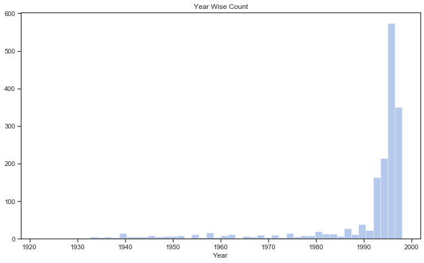

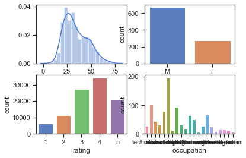

```python
##  your answers here
# HINT: use distplot for age and countplot for gender,ratings,occupation.
sns.set(style="ticks", palette="muted")

plt.figure(figsize=(12,7))
# Hint : Use displot without kde for release year or line plot showing year wise count
sns.distplot(df_item['Year'], kde=False, axlabel='Year', label='Year Wise Count')
plt.title('Year Wise Count')
plt.show()

f, axs = plt.subplots(2, 2)
plt.figure(figsize=(5,5))
sns.distplot(df_user['age'], ax=axs[0,0])
sns.countplot(x='gender', data=df_user, ax=axs[0,1])
sns.countplot(x='rating', data=df_data, ax=axs[1,0])
sns.countplot(x='occupation', data=df_user, ax=axs[1,1])
plt.show()
```

### 8. Visualize how popularity of genres has changed over the years - 10 marks

Note that you need to use the number of releases in a year as a parameter of popularity of a genre

Hint

1: you need to reach to a data frame where the release year is the index and the genre is the column names (one cell shows the number of release in a year in one genre) or vice versa. Once that is achieved, you can either use univariate plots or can use the heatmap to visualise all the changes over the years in one go.

Hint 2: Use groupby on the relevant column and use sum() on the same to find out the nuumber of releases in a year/genre.

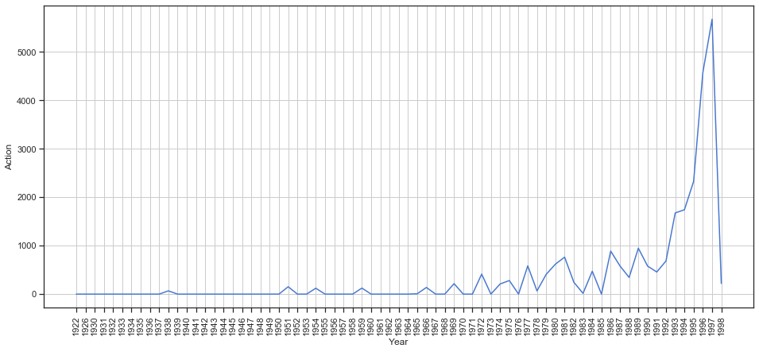

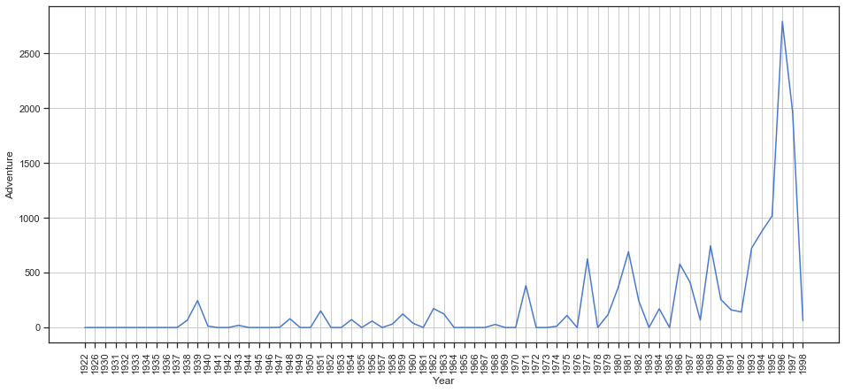

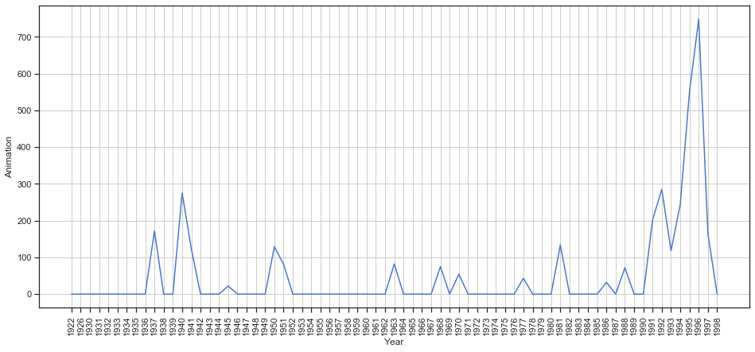

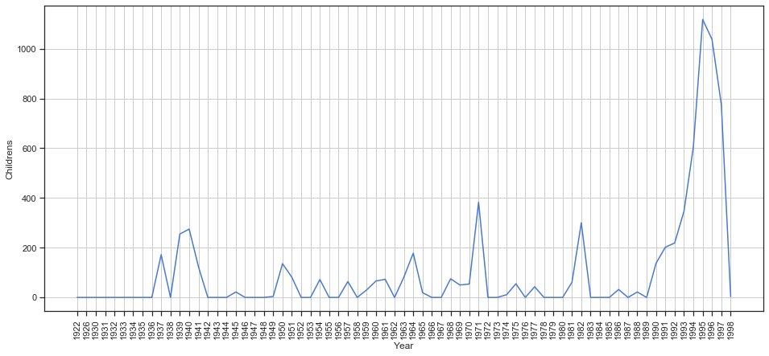

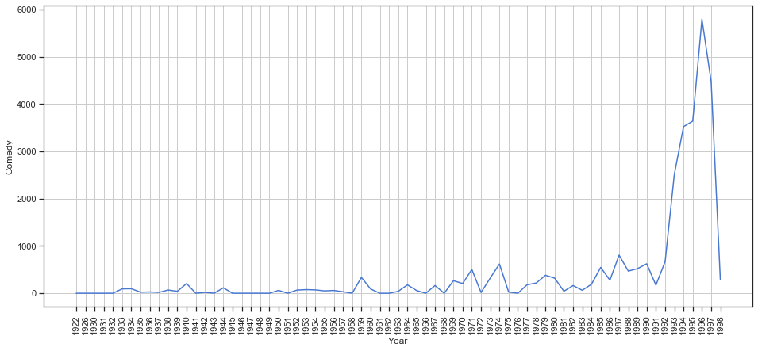

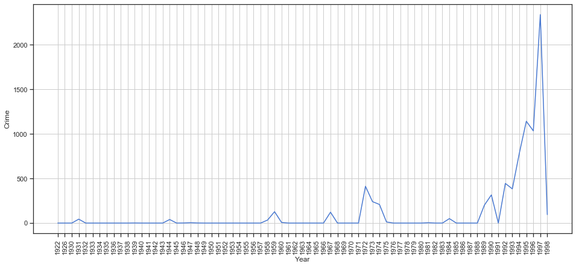

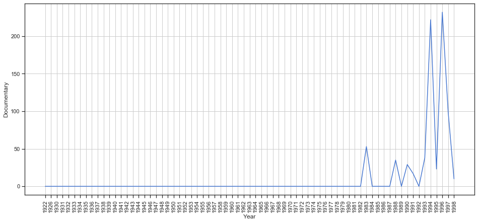

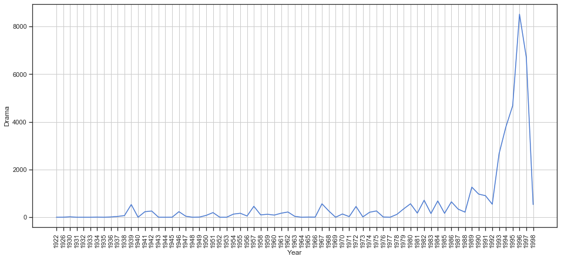

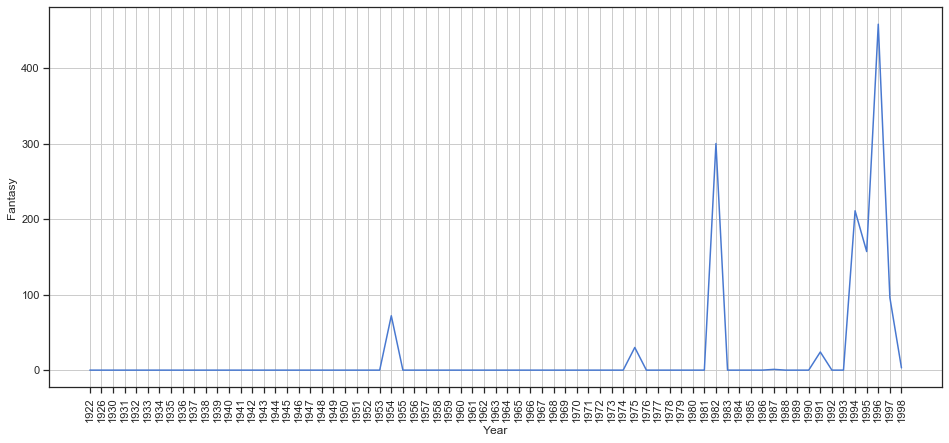

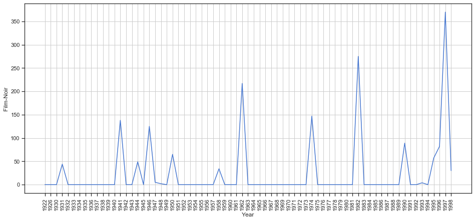

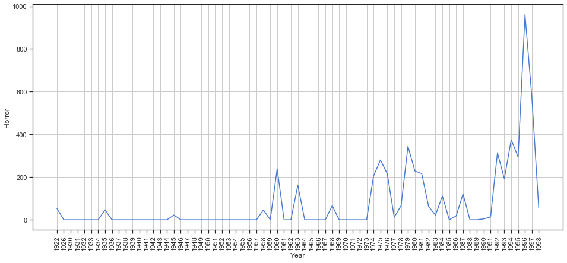

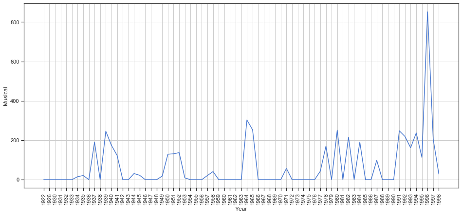

[6 more figures not shown]

```python
#Your answer here
df_DataItem = df_data.merge(df_item,on='movie id',how='outer')

for genre_type in ['Action', 'Adventure', 'Animation', 'Childrens', 'Comedy', 'Crime', 'Documentary',
                   'Drama', 'Fantasy', 'Film-Noir', 'Horror', 'Musical', 'Mystery',
                   'Romance', 'Sci-Fi', 'Thriller', 'War', 'Western']:

        results = df_DataItem.groupby(['Year'],as_index=False)[genre_type].sum()
        plt.figure(figsize=(16,7))
        plt.grid(b='on')
        plt.xticks(rotation=90)
        plt.plot('Year', genre_type, data=results)
        plt.ylabel(genre_type)
        plt.xlabel('Year')
        plt.show()
```

### 9. Find the top 25 movies according to average ratings such that each movie has number of ratings more than 100 - 10 marks

Hint :

1. First find the movies that have more than 100 ratings(use merge, groupby and count). Extract the movie titles in a list.
2. Find the average rating of all the movies and sort them in the descending order. You will have to use the .merge() function to reach to a data set through which you can get the names and the average rating.
3. Use isin(list obtained from 1) to filter out the movies which have more than 100 ratings.

Note: This question will need you to research about groupby and apply your findings. You can find more on groupby on https://realpython.com/pandas-groupby/.

```python
# your answer here
top_movie_ratings = df_DataItem.groupby('movie title').agg({'rating':[np.size, np.mean]})
mat = top_movie_ratings['rating']['size'] >= 100
top_movies = top_movie_ratings[mat]

top_movies.columns =['Number', 'Mean']


top_movies_25 = top_movies.sort_values(by=['Mean'], ascending=False)[:25]

print(top_movies_25.head(25))

# top_movies = top_movies.sort_values(by=np.size, ascending=False)[:25]
# most_rated = df_DataItem.groupby('movie title').size().sort_values(ascending=False)[:25]
# most_rated
```

```
                                                    Number      Mean
movie title
Close Shave, A                                         112  4.491071
Schindler's List                                       298  4.466443
Wrong Trousers, The                                    118  4.466102
Casablanca                                             243  4.456790
Shawshank Redemption, The                              283  4.445230
Rear Window                                            209  4.387560
Usual Suspects, The                                    267  4.385768
Star Wars                                              583  4.358491
12 Angry Men                                           125  4.344000
Citizen Kane                                           198  4.292929
To Kill a Mockingbird                                  219  4.292237
One Flew Over the Cuckoo's Nest                        264  4.291667
Silence of the Lambs, The                              390  4.289744
North by Northwest                                     179  4.284916
Godfather, The                                         413  4.283293
Secrets & Lies                                         162  4.265432
Good Will Hunting                                      198  4.262626
Manchurian Candidate, The                              131  4.259542
Dr. Strangelove or: How I Learned to Stop Worry...     194  4.252577
Raiders of the Lost Ark                                420  4.252381
Vertigo                                                179  4.251397
Titanic                                                350  4.245714
Lawrence of Arabia                                     173  4.231214
Maltese Falcon, The                                    138  4.210145
Empire Strikes Back, The                               367  4.204360
```

### 10. See gender distribution across different genres check for the validity of the below statements - 10 marks

- Men watch more drama than women
- Women watch more Sci-Fi than men
- Men watch more Romance than women
1. There is no need to conduct statistical tests around this. Just compare the percentages and comment on the validity of the above statements.
2. you might want ot use the .sum(), .div() function here.
3. Use number of ratings to validate the numbers. For example, if out of 4000 ratings received by women, 3000 are for drama, we will assume that 75% of the women watch drama.

#### Conclusion:

```python
df_DataItemUser = df_DataItem.merge(df_user,on='user id',how='outer')
print('Total gender = \n', df_DataItemUser.groupby('gender')['gender'].count())
print('Total Drama = \n',df_DataItemUser.groupby('gender')['Drama'].sum())
print('Total Sci-Fi = \n',df_DataItemUser.groupby('gender')['Sci-Fi'].sum())
print('Total Romance = \n',df_DataItemUser.groupby('gender')['Romance'].sum())
```

```
Total gender =
 gender
F    25740
M    74260
Name: gender, dtype: int64
Total Drama =
 gender
F    11008.0
M    28887.0
Name: Drama, dtype: float64
Total Sci-Fi =
 gender
F     2629.0
M    10101.0
Name: Sci-Fi, dtype: float64
Total Romance =
 gender
F     5858.0
M    13603.0
Name: Romance, dtype: float64
```

```python
countDrama = df_DataItemUser.groupby('gender')['Drama'].sum()
countSciFi = df_DataItemUser.groupby('gender')['Sci-Fi'].sum()
countRomance = df_DataItemUser.groupby('gender')['Romance'].sum()
countTotal = df_DataItemUser.groupby('gender')['gender'].count()
print(' Drama F = ', countDrama.loc['F'])
print(' Drama M = ', countDrama.loc['M'])
print(' SciFi F = ', countSciFi.loc['F'])
print(' SciFi M = ', countSciFi.loc['M'])
print(' Romance F = ', countRomance.loc['F'])
print(' Romance M = ', countRomance.loc['M'])
print(' Total F = ', countTotal.loc['F'])
print(' Total M = ', countTotal.loc['M'])
df_DataItemUser['Drama'].sum()
```

```
 Drama F =  11008.0
 Drama M =  28887.0
 SciFi F =  2629.0
 SciFi M =  10101.0
 Romance F =  5858.0
 Romance M =  13603.0
 Total F =  25740
 Total M =  74260
```

```
39895.0
```

```python
countDrama.loc['F']/countTotal.loc['F']
```

```
0.42766122766122766
```

```python
countDrama.loc['M']/countTotal.loc['M']
```

```
0.3889981147320226
```

Therfore "Men watch more drama than women" is False because 43% of women versus 39% for men

```python
countSciFi.loc['F']/countTotal.loc['F']
```

```
0.10213675213675213
```

```python
countSciFi.loc['M']/countTotal.loc['M']
```

```
0.13602208456773499
```

Therfore "Women watch more Sci-Fi than men: is False because 10% of women versus 14% for men

```python
countRomance.loc['F']/countTotal.loc['F']
```

```
0.2275835275835276
```

```python
countRomance.loc['M']/countTotal.loc['M']
```

```
0.1831807164018314
```

Therfore "Men watch more Romance than women" is False because 23% of women versus 18% for men